# UrbanConnectivity-Metaanalysis-updates

Andrew Habrich

19 March, 2024

# 1 Meta-analysis preparation overview

The following R packages (and their versions) were used to generate this report.

```
##        knitr       ggpubr DataExplorer      emmeans      metafor     numDeriv
##       "1.45"      "0.6.0"      "0.8.3"     "1.10.0"      "4.4-0" "2016.8-1.1"
##      metadat       Matrix          see       report   parameters  performance
##      "1.2-0"      "1.6-5"      "0.8.2"      "0.5.8"     "0.21.5"     "0.10.9"
##   modelbased      insight   effectsize   datawizard  correlation   bayestestR
##      "0.8.7"     "0.19.8"      "0.8.6"      "0.9.1"      "0.8.4"     "0.13.2"
##    easystats    lubridate      forcats      stringr        dplyr        purrr
##      "0.7.0"      "1.9.3"      "1.0.0"      "1.5.1"      "1.1.4"      "1.0.2"
##        readr        tidyr       tibble      ggplot2    tidyverse
##      "2.1.5"      "1.3.1"      "3.2.1"      "3.5.0"      "2.0.0"
```

# 2 Data

This is data extracted for 87 studies, with 595 effect sizes. In addition, there are 13 other studies that report data for *(generalized) linear mixed models*, but I am unsure how comparable they are.

The data includes raw effect sizes (Fisher’s z transformed correlation coefficients) for the relationship between a variety of response variables (**species richness, abundance, occurrence, genetic differentiation and a few others**), and metrics of connectivity categorized into different types following their definitions (as described by (Kindlmann and Burel 2008), (Kupfer 2012), and (Keeley, Beier, and Jenness 2021).

The following figures show the distribution of effect sizes across different categories of the data.

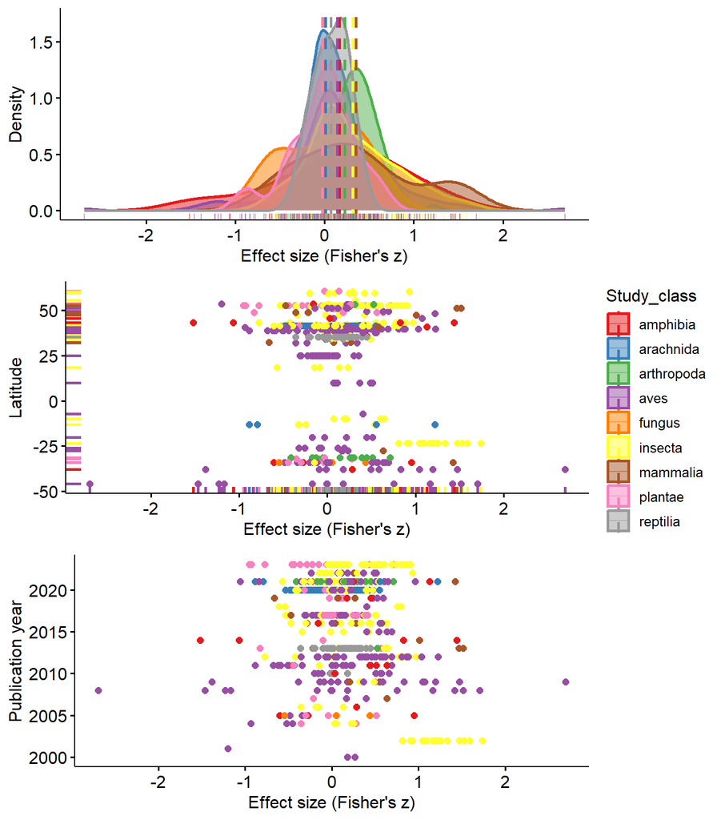

For the first density plot, the dashed lines are the **mean** effects. All the plots are grouped by the study taxa, and the raw correlation coefficients were transformed into the Fisher’s z scale.

# 3 Journal and study information

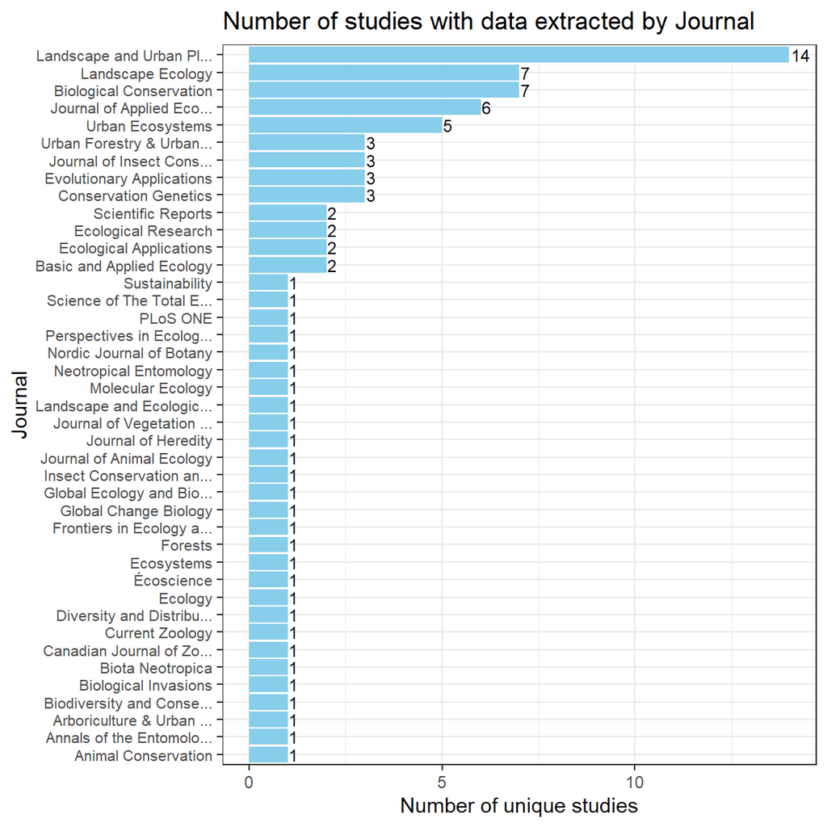

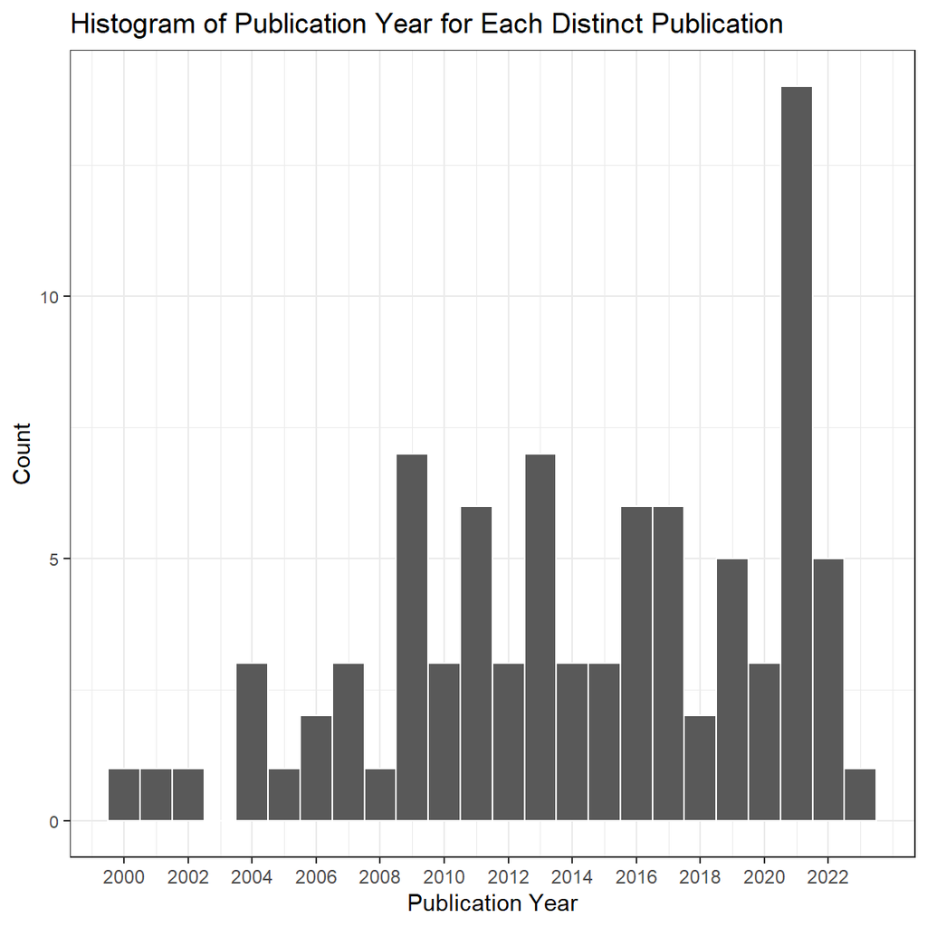

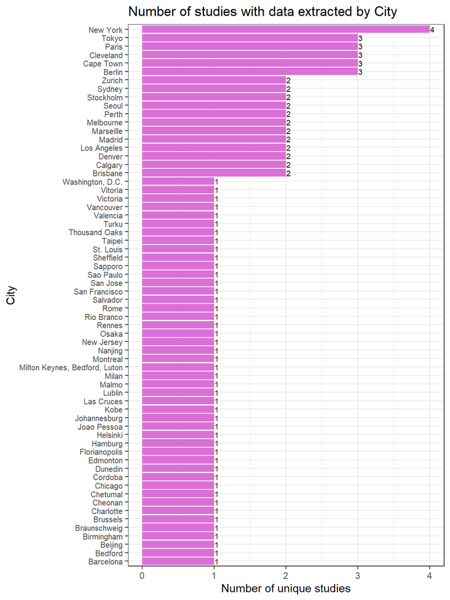

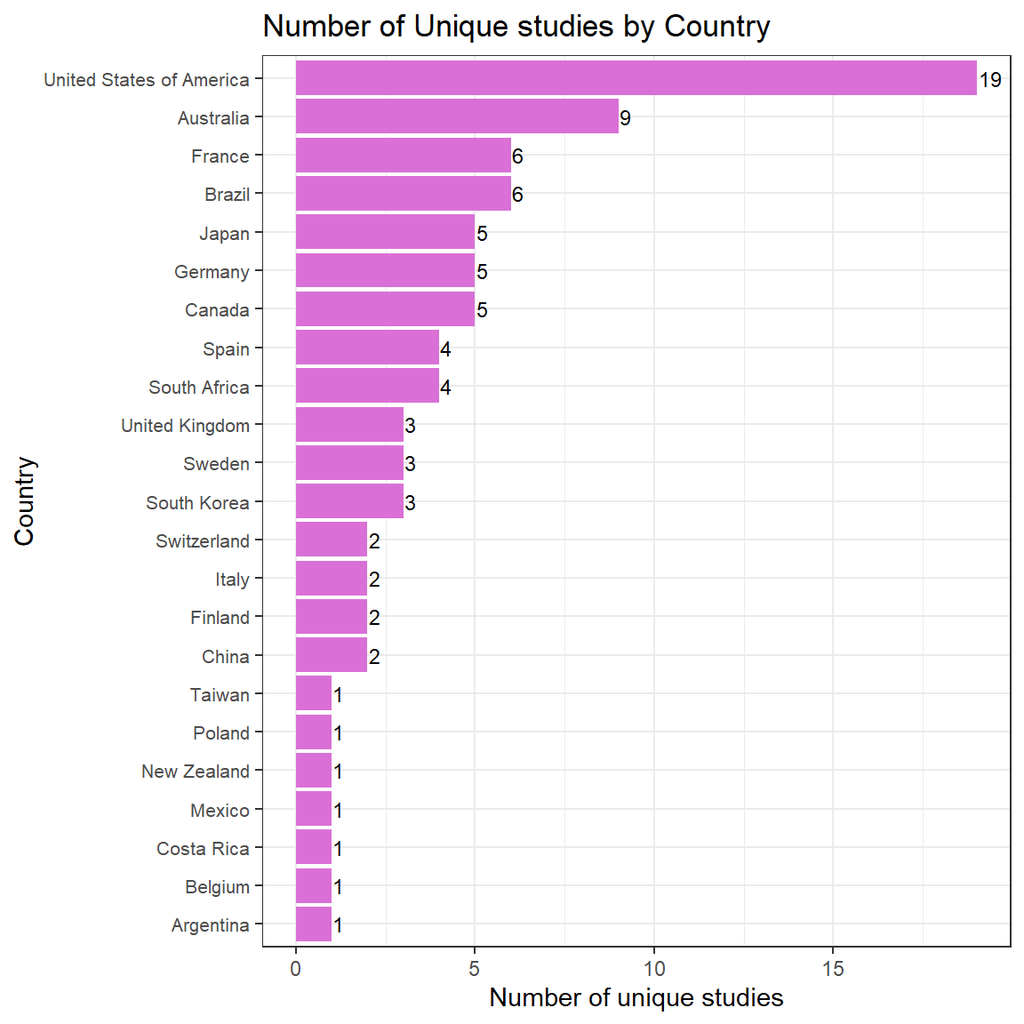

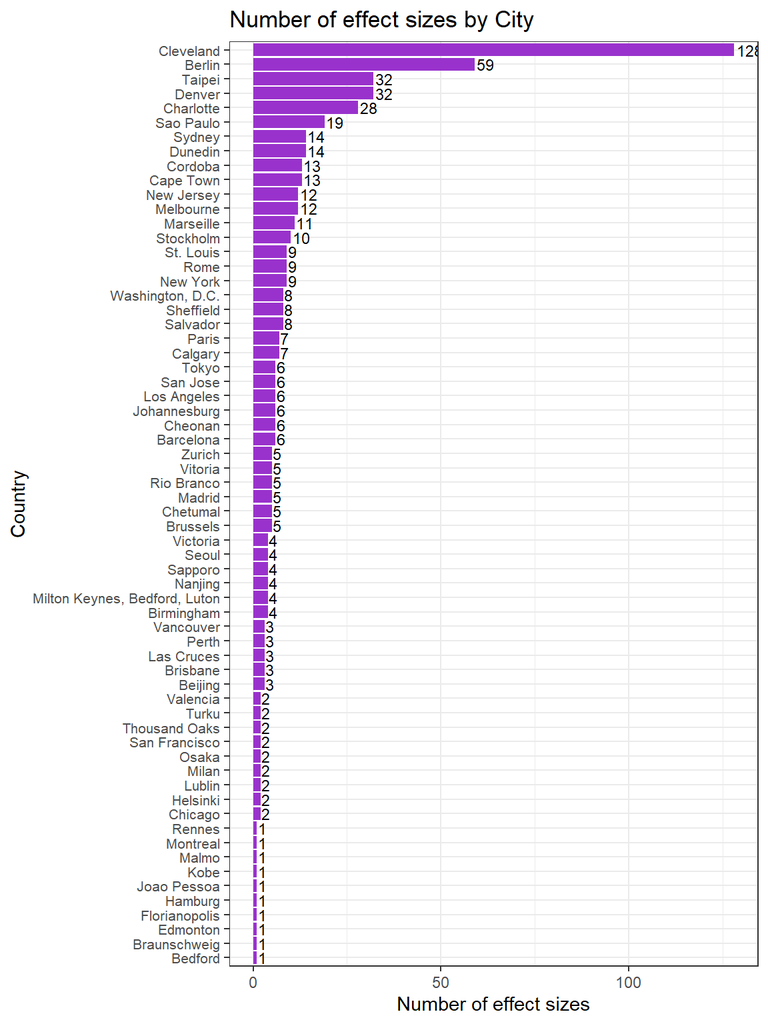

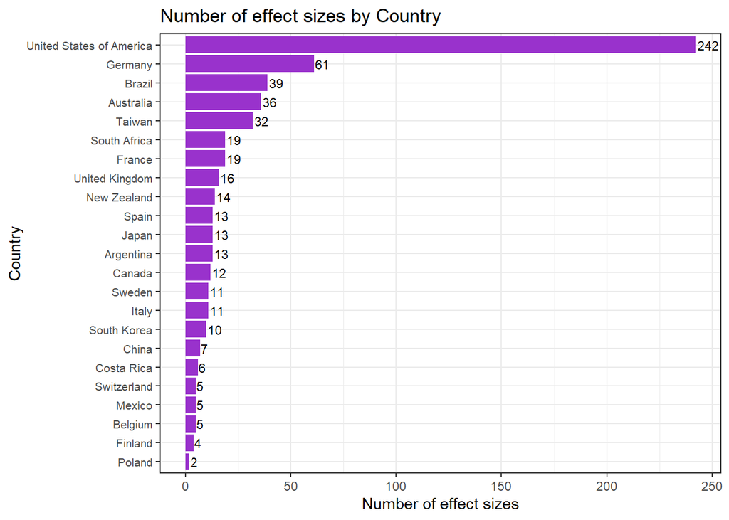

# 4 Taxonomic information

**Note** that the taxonomic information is not complete for all studies, and the taxonomic resolution varies between studies; e.g. studies with *‘arthropoda’*, and many studies with *‘plantae’* as focal taxa are only reported at a broad taxonomic level.

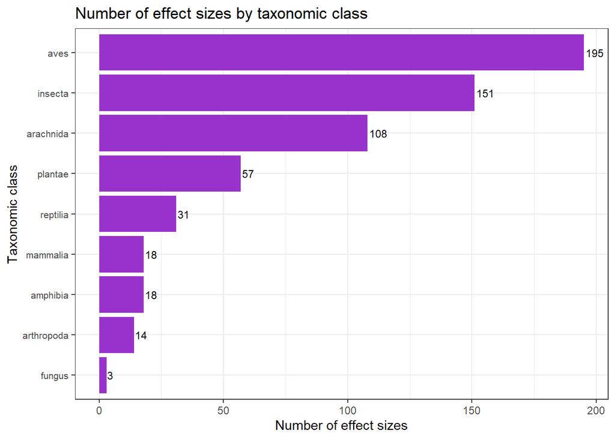

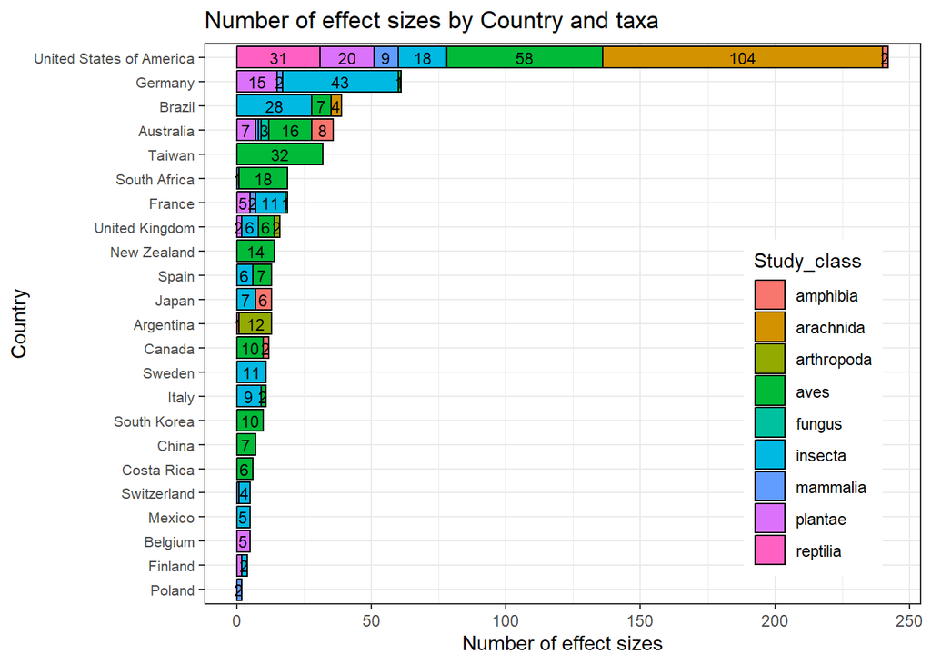

# 5 Connectivity metrics

Connectivity metrics were binned based on their **type** (structural, potential, functional) and the **feature** of the landscape that connectivity is being assessed for, based on author’s descriptions of the metric and definitions from (Keeley, Beier, and Jenness 2021) and [Fragstats documentation](https://www.fragstats.org/index.php/documentation). The following figures show the distribution of effect sizes across these categories.

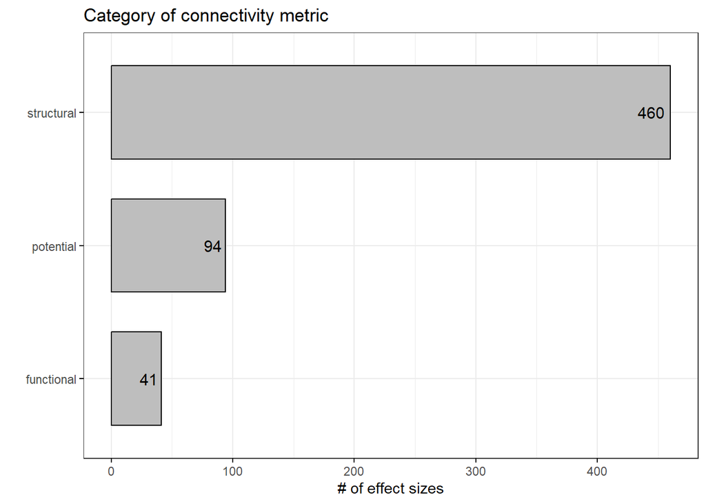

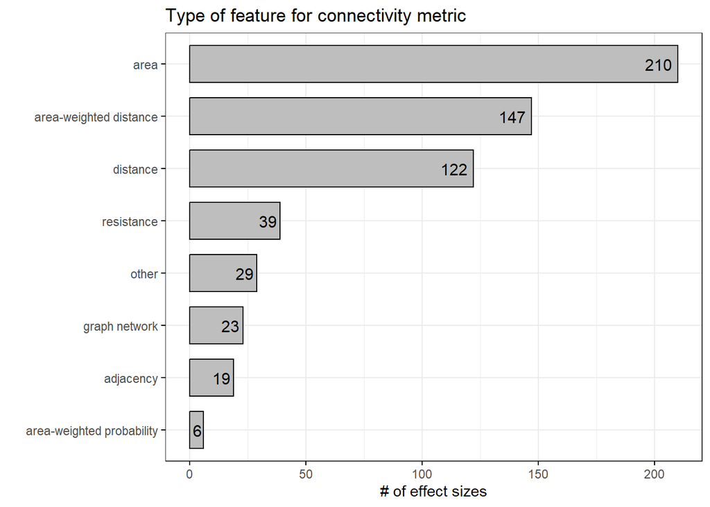

The most common connectivity metrics were based on ‘habitat’ area in a buffer (typically based on dispersal distances), or euclidean distances between sites/patches. Because of the large spectrum of metrics used, it is likely that the categories these metrics are binned into (the two previous figures) will be used as moderators in the meta-analysis.

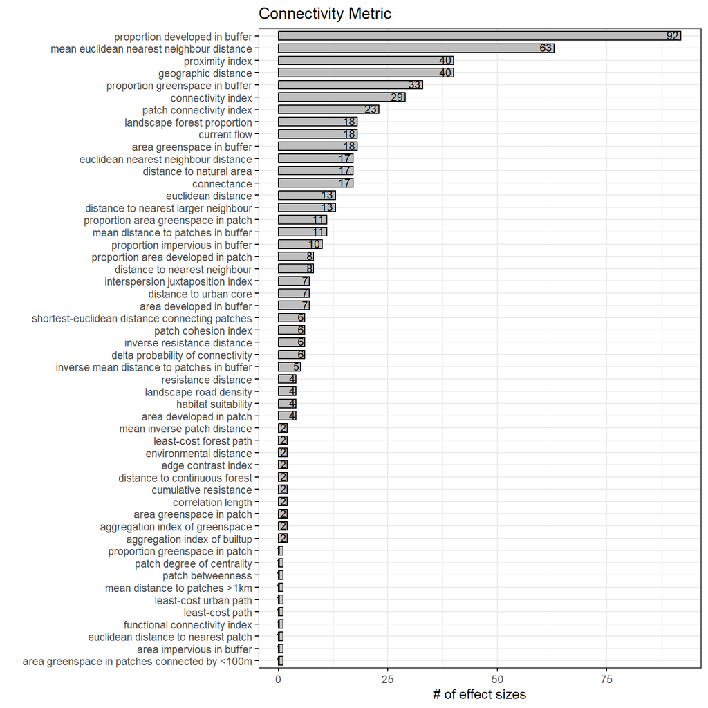

# 6 Response metrics

Many papers report multiple response metrics, particularly for species richness and abundance or occurrence and abundance. Genetic studies often only report one response metric related to connectivity; genetic differentiation (a.k.a. genetic ‘distance’), but these are sometimes based on different genetic markers (e.g. microsatellites, SNPs, etc.).

One major question for the meta-analysis: **How to handle multiple response metrics?**

- Everything into **a global model** with to get an ‘overall’ effect of connectivity on biodiversity outcomes with and without moderators coded for metric type and response type.
- Seperate **meta-analyses for each of the response metrics**. Since each of these response metrics capture different aspects of biodiversity, it is likely that the mechanisms of how connectivity impacts them isn’t the same.

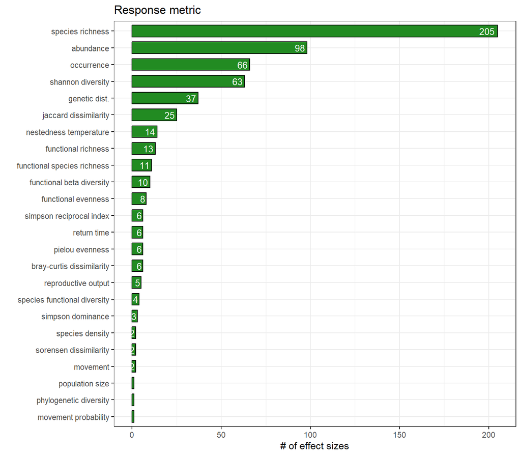

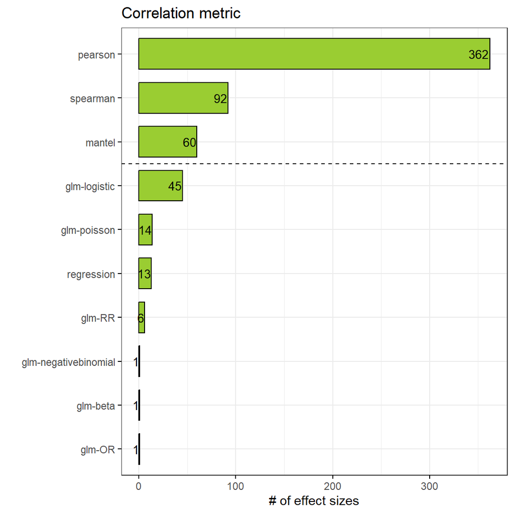

# 7 Next steps:

- Finish extracting relevant information for the rest of eligible papers.
- Write a script for conducting a global meta-analysis for all effect sizes.
- Finish writing script for conducting analysis meta-regression per connectivity metric and biodiversity metric that have a large enough sample size.
- Estimate variance-covariance matrix for multiple effect sizes that come from the same study, for dependent effect sizes. Incorporate into the model and evaluate the impact of this on the results.

# 8 References:

## 8.1 References for the data extracted

| First Author | Year | Journal | DOI |
| --- | --- | --- | --- |
| Angold | 2006 | Science of The Total Environment | 10.1016/j.scitotenv.2005.08.035 |
| App | 2022 | Landscape and Urban Planning | 10.1016/j.landurbplan.2021.104347 |
| Aronson | 2017 | Biological Invasions | 10.1007/s10530-017-1583-1 |
| Balbi | 2021 | Journal of Applied Ecology | 10.1111/1365-2664.13800 |
| Barr | 2021 | Landscape and Urban Planning | 10.1016/j.landurbplan.2021.104177 |
| Braaker | 2014 | Ecological Applications | 10.1890/13-1088.1 |
| Brown | 2002 | Journal of Insect Conservation | 10.1023/A:1024462523826 |
| Calder | 2015 | Biological Conservation | 10.1016/j.biocon.2015.04.021 |
| Carlen | 2021 | Evolutionary Applications | 10.1007/s10531-012-0339-6 |
| Chang | 2017 | Landscape and Urban Planning | 10.1016/j.landurbplan.2016.05.028 |
| Choi | 2021 | Landscape Ecology | 10.1007/s10980-020-01165-8 |
| Cortés-Arzola | 2021 | Annals of the Entomological Society of America | 10.1093/aesa/saab017 |
| Delaney | 2010 | PLoS ONE | 10.1371/journal.pone.0012767 |
| Delgado de la flor | 2020 | Journal of Applied Ecology | 10.1111/1365-2664.13636 |
| Dri | 2021 | Biological Conservation | 10.1016/j.biocon.2021.109064 |
| Drinnan | 2005 | Biological Conservation | 10.1016/j.biocon.2005.01.040 |
| Dures | 2010 | Biological Conservation | 10.1016/j.biocon.2009.12.019 |
| Eckert | 2017 | Insect Conservation and Diversity | 10.1111/icad.12221 |
| Enedino | 2018 | Perspectives in Ecology and Conservation | 10.1016/j.pecon.2017.11.001 |
| Evans | 2017 | Frontiers in Ecology and Evolution | 10.3389/fevo.2017.00063 |
| Fabian | 2021 | Urban Forestry & Urban Greening | 10.1016/j.ufug.2021.127107 |
| Fattorini | 2016 | Journal of Insect Conservation | 10.1007/s10841-016-9900-z |
| Fernández-Juricic | 2004 | Landscape and Urban Planning | 10.1016/j.landurbplan.2003.09.001 |
| Fernández-Juricic | 2000 | Ecological Research | 10.1046/j.1440-1703.2000.00358.x |
| Fitzgibbon | 2007 | Landscape Ecology | 10.1007/s10980-007-9139-x |
| Furman | 2016 | Conservation Genetics | 10.1007/s10592-015-0757-6 |
| Fusco | 2021 | Evolutionary Applications | 10.1111/eva.13025 |
| Fuyuki | 2014 | Urban Forestry & Urban Greening | 10.1016/j.ufug.2013.11.003 |
| Ganzhorn | 2001 | Basic and Applied Ecology | 10.1078/1439-1791-00040 |
| Grafius | 2017 | Landscape Ecology | 10.1007/s10980-017-0548-1 |

[output cut: 57 more lines]

## References for this document

Keeley, Annika T. H., Paul Beier, and Jeff S. Jenness. 2021. “Connectivity Metrics for Conservation Planning and Monitoring.” *Biological Conservation* 255 (March): 109008. https://doi.org/10.1016/j.biocon.2021.109008.

Kindlmann, Pavel, and Francoise Burel. 2008. “Connectivity Measures: A Review.” *Landscape Ecology*, July. https://doi.org/10.1007/s10980-008-9245-4.

Kupfer, John A. 2012. “Landscape Ecology and Biogeography: Rethinking Landscape Metrics in a Post-FRAGSTATS Landscape.” *Progress in Physical Geography: Earth and Environment* 36 (3): 400–420. https://doi.org/10.1177/0309133312439594.